# Data Visualization: Ford Go Bike 2017

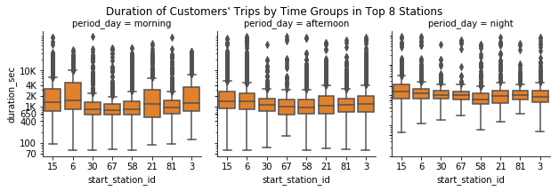

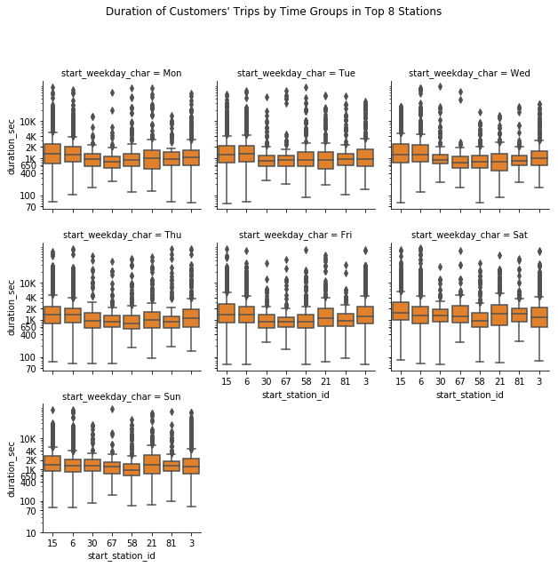

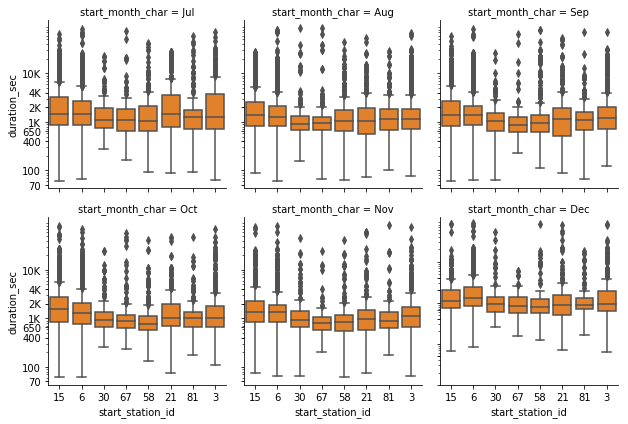

```python
# 3 Categorical variables and 1 numeric variables: Use FacetGrid and a Boxplot here.
# Top 8 trips station by times (time of day, weekdays, months) in the log-transformed duration of trips distribution and in customers

base_color = sb.color_palette()[1]
for i in range(1, 4):
    plt.subplots_adjust(top=0.85)
    g.fig.suptitle('Duration of Customers\' Trips by Time Groups in Top 8 Stations')
    g = sb.FacetGrid(data=df_cust, col=times_chr[i-1], col_wrap=3)
    g.map(sb.boxplot,'start_station_id', 'duration_sec', order=[15,6,30,67,58,21,81,3], color=base_color)
    plt.yscale('log')
    plt.yticks([10,50,100,400,650,1000,2000,4000,10000], [10,70,100,400,650,'1K','2K','4K','10K']);
```

**After separating subscribers from customers, I found that the median trip duration for customers is between 1,000 and 2,000 seconds. Trips taken at night and in December are longer. The longer durations in December make sense due to the holiday season, but the longer trips at night require further investigation.**

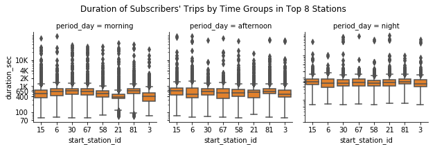

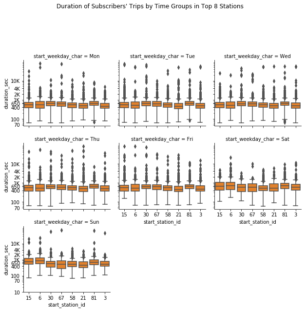

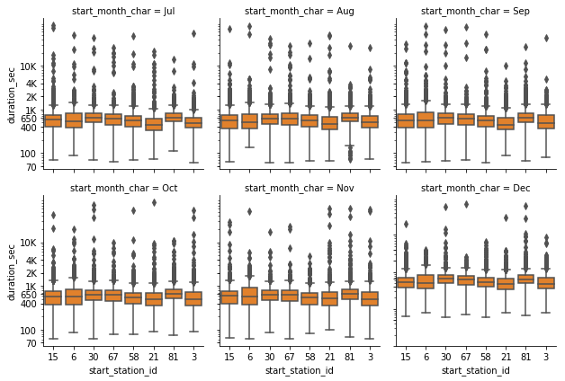

```python
# Now, let’s look at the subscribers
# (4) Top 8 trips station by times (period of day, weekdays, months) in the log-transformed duration of trips distribution and in subscribers

base_color = sb.color_palette()[1]

for i in range(1, 4):
    plt.subplots_adjust(top=0.8)
    g.fig.suptitle('Duration of Subscribers\' Trips by Time Groups in Top 8 Stations')
    g = sb.FacetGrid(data=df_sub, col=times_chr[i-1], col_wrap=3)
    g.map(sb.boxplot,'start_station_id', 'duration_sec', order=[15,6,30,67,58,21,81,3], color=base_color)
    plt.yscale('log')
    plt.yticks([10,50,100,400,650,1000,2000,4000,10000], [10,70,100,400,650,'1K','2K','4K','10K']);
```

### Features reinforce each other when analyzed by location and time

Separating users into customers and subscribers reveals clearer patterns:

- Customers are likely tourists or occasional riders. They tend to ride more on weekends and in the summer, and their trips are more common at tourist-heavy locations such as the Ferry Building and Embarcadero (near the piers).
- Subscribers appear to be commuters. Their trips are more frequent on weekdays, and after the program launched, their usage gradually increased and then declined as the weather became colder.

This shows that user type, time, and location together provide a much richer picture than any single feature alone.

### Interesting or surprising interactions between features

When we separate the data by user type (customers vs. subscribers), the patterns become much clearer. User type not only affects when and where people ride, but also the duration of their trips:

- Customers tend to have longer trips, with median durations around 1,000–2,000 seconds.
- Subscribers have shorter trips on average, with medians around 650 seconds, which is consistent with commute-style riding.
- For both groups, trips in December are longer than in other months, likely due to the holiday season and more leisure-oriented riding.

So, user type + time of year together create a stronger signal than looking at time alone.

## V. Proposal for Next Steps

1. **Gender differences**: The current features do not clearly explain the gap between male and female riders. Additional data (e.g., trip purpose, bike availability, station safety, time-of-day lighting, or survey data) would help investigate this further.
1. **Longer nighttime trips**: Trip durations are consistently longer at night than during other times of day. This pattern should be explored with more features, such as day type (weekday vs. weekend), user purpose, or even weather/holiday effects, to understand why riders stay longer on bikes at night.

## VI. Reference

1. Dataset,2017-fordgobike-tripdata.csv, https://s3.amazonaws.com/fordgobike-data/index.html
2. license https://assets.fordgobike.com/data-license-agreement.html